# Results - Daily Annuli Upwind New Wells

# Gases

## Pollutant: NO2

### Urban

Descriptive statistics:

- n monitor days = 594362
- n monitors in analytic data = 146

#### Adjusted linear regression model with monitor + month + basin:year FE

```
##
## Call:
##    felm(formula = no2_concentration_daily_max ~ wells_new_0to1km +      wells_new_1to2km + wells_new_2to3km + wells_new_3to4km +      wells_new_4to5km + wells_new_5to6km + wells_new_6to7km +      wells_new_7to8km + wells_new_8to9km + wells_new_9to10km +      wells_dw_new_0to1km + wells_dw_new_1to…
##
## Residuals:
##     Min      1Q  Median      3Q     Max
## -52.979  -6.955  -0.820   5.773 143.763
##
## Coefficients:
##                       Estimate Std. Error t value Pr(>|t|)
## wells_new_0to1km            NA         NA      NA       NA
## wells_new_1to2km      0.847167   0.315270   2.687  0.00721 **
## wells_new_2to3km      0.125452   0.209065   0.600  0.54846
## wells_new_3to4km     -0.502018   0.127851  -3.927 8.62e-05 ***
## wells_new_4to5km     -0.196707   0.154586  -1.272  0.20321
## wells_new_5to6km      0.320036   0.061052   5.242 1.59e-07 ***
## wells_new_6to7km      0.022201   0.107729   0.206  0.83673
## wells_new_7to8km     -0.101212   0.048531  -2.085  0.03703 *
## wells_new_8to9km      0.146147   0.099449   1.470  0.14168
## wells_new_9to10km     0.363742   0.124387   2.924  0.00345 **
## wells_dw_new_0to1km         NA         NA      NA       NA
## wells_dw_new_1to2km  -0.622338   0.347268  -1.792  0.07312 .
## wells_dw_new_2to3km   0.547803   0.192095   2.852  0.00435 **
## wells_dw_new_3to4km   0.353663   0.114491   3.089  0.00201 **
## wells_dw_new_4to5km  -0.358277   0.197007  -1.819  0.06897 .
## wells_dw_new_5to6km  -0.528611   0.068330  -7.736 1.03e-14 ***
## wells_dw_new_6to7km  -0.092558   0.123424  -0.750  0.45330
## wells_dw_new_7to8km   0.646412   0.065164   9.920  < 2e-16 ***
## wells_dw_new_8to9km  -0.344243   0.108965  -3.159  0.00158 **
## wells_dw_new_9to10km  0.200315   0.094962   2.109  0.03491 *
## narr_precip          -0.471490   0.006162 -76.511  < 2e-16 ***
## narr_temp             0.601545   0.005742 104.762  < 2e-16 ***
## ---
## Signif. codes:  0 '***' 0.001 '**' 0.01 '*' 0.05 '.' 0.1 ' ' 1
##
## Residual standard error: 11.08 on 236662 degrees of freedom
##   (357513 observations deleted due to missingness)
## Multiple R-squared(full model): 0.5619   Adjusted R-squared: 0.5616
## Multiple R-squared(proj model): 0.07091   Adjusted R-squared: 0.07018
## F-statistic(full model): 1632 on 186 and 236662 DF, p-value: < 2.2e-16
## F-statistic(proj model): 821.1 on 22 and 236662 DF, p-value: < 2.2e-16
## *** Standard errors may be too high due to more than 2 groups and exactDOF=FALSE
```

**Upwind**

*Table*

```
## # A tibble: 10 x 5
##    distance direction point_est ci_lower  ci_upper
##    <chr>    <chr>         <dbl>    <dbl>     <dbl>
##  1 0-1      Upwind     NaN      NaN      NaN
##  2 1-2      Upwind       0.847    0.229    1.47
##  3 2-3      Upwind       0.125   -0.284    0.535
##  4 3-4      Upwind      -0.502   -0.753   -0.251
##  5 4-5      Upwind      -0.197   -0.500    0.106
##  6 5-6      Upwind       0.320    0.200    0.440
##  7 6-7      Upwind       0.0222  -0.189    0.233
##  8 7-8      Upwind      -0.101   -0.196   -0.00609
##  9 8-9      Upwind       0.146   -0.0488   0.341
## 10 9-10     Upwind       0.364    0.120    0.608
```

*Figure*

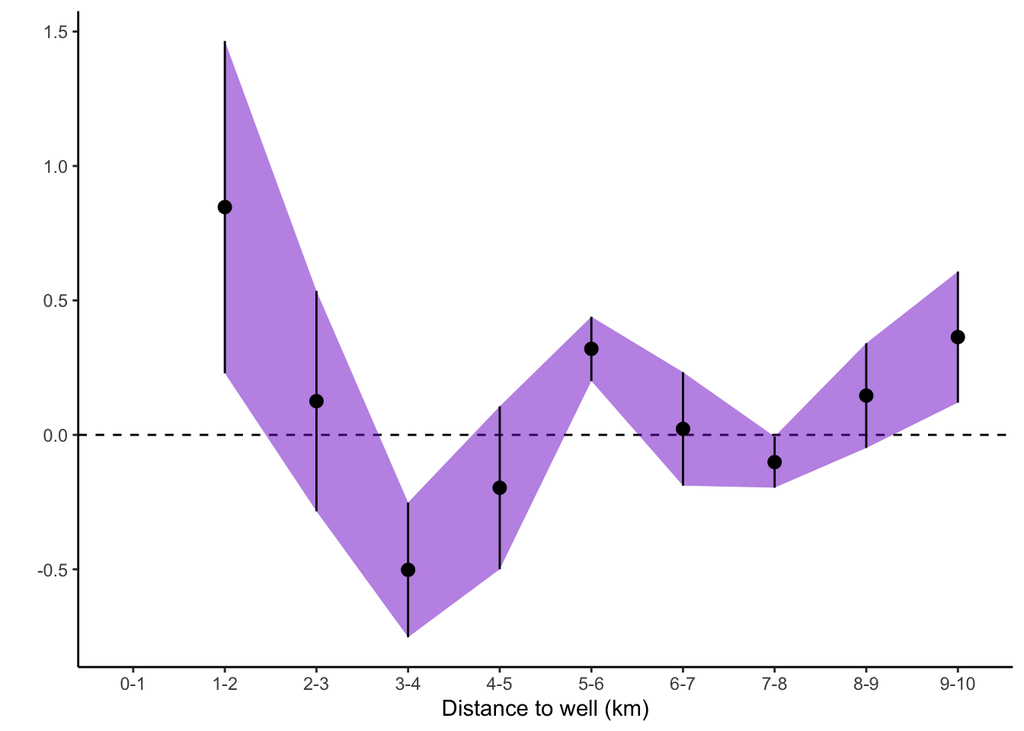

**Downwind**

*Table*

```
## # A tibble: 10 x 5
##    distance direction point_est ci_lower ci_upper
##    <chr>    <chr>         <dbl>    <dbl>    <dbl>
##  1 0-1      Downwind   NaN      NaN      NaN
##  2 1-2      Downwind    -0.622   -1.30     0.0583
##  3 2-3      Downwind     0.548    0.171    0.924
##  4 3-4      Downwind     0.354    0.129    0.578
##  5 4-5      Downwind    -0.358   -0.744    0.0279
##  6 5-6      Downwind    -0.529   -0.663   -0.395
##  7 6-7      Downwind    -0.0926  -0.334    0.149
##  8 7-8      Downwind     0.646    0.519    0.774
##  9 8-9      Downwind    -0.344   -0.558   -0.131
## 10 9-10     Downwind     0.200    0.0142   0.386
```

*Figure*

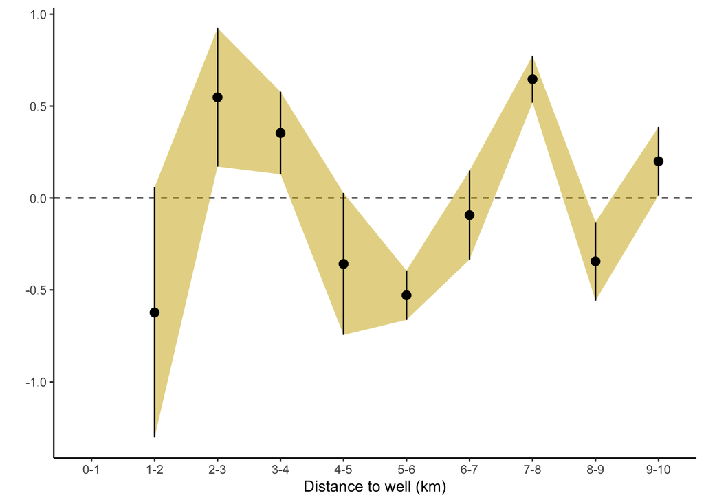

### Rural

Descriptive statistics:

- n monitor days = 123690
- n monitors in analytic data = 31

#### Adjusted linear regression model with monitor + month + basin:year FE

```
##
## Call:
##    felm(formula = no2_concentration_daily_max ~ wells_new_0to1km +      wells_new_1to2km + wells_new_2to3km + wells_new_3to4km +      wells_new_4to5km + wells_new_5to6km + wells_new_6to7km +      wells_new_7to8km + wells_new_8to9km + wells_new_9to10km +      wells_dw_new_0to1km + wells_dw_new_1to…
##
## Residuals:
##     Min      1Q  Median      3Q     Max
## -30.493  -3.513  -0.462   2.652 153.196
##
## Coefficients:
##                       Estimate Std. Error t value Pr(>|t|)
## wells_new_0to1km      1.407230   1.003122   1.403 0.160667
## wells_new_1to2km      0.259056   1.086354   0.238 0.811522
## wells_new_2to3km     -0.514125   0.267278  -1.924 0.054415 .
## wells_new_3to4km      0.638042   0.261887   2.436 0.014840 *
## wells_new_4to5km     -0.580901   0.160690  -3.615 0.000301 ***
## wells_new_5to6km      0.485698   0.220237   2.205 0.027434 *
## wells_new_6to7km      0.642952   1.333524   0.482 0.629704
## wells_new_7to8km     -2.519243   0.590591  -4.266 2.00e-05 ***
## wells_new_8to9km      0.240199   0.422794   0.568 0.569954
## wells_new_9to10km    -1.054789   0.358885  -2.939 0.003293 **
## wells_dw_new_0to1km   1.217865   1.763379   0.691 0.489793
## wells_dw_new_1to2km  -0.874640   1.633691  -0.535 0.592391
## wells_dw_new_2to3km  -1.465114   0.152207  -9.626  < 2e-16 ***
## wells_dw_new_3to4km   0.025124   0.111000   0.226 0.820934
## wells_dw_new_4to5km   0.516652   0.239848   2.154 0.031238 *
## wells_dw_new_5to6km   1.663710   0.321867   5.169 2.36e-07 ***
## wells_dw_new_6to7km   0.406189   0.960907   0.423 0.672505
## wells_dw_new_7to8km   1.237594   0.631828   1.959 0.050147 .
## wells_dw_new_8to9km  -0.325551   0.512703  -0.635 0.525450
## wells_dw_new_9to10km  1.766865   0.364275   4.850 1.24e-06 ***
## narr_precip          -0.180050   0.006267 -28.728  < 2e-16 ***
## narr_temp             0.274823   0.007389  37.193  < 2e-16 ***
## ---
## Signif. codes:  0 '***' 0.001 '**' 0.01 '*' 0.05 '.' 0.1 ' ' 1
##
## Residual standard error: 6.321 on 57645 degrees of freedom
##   (65943 observations deleted due to missingness)
## Multiple R-squared(full model): 0.6305   Adjusted R-squared: 0.6299
## Multiple R-squared(proj model): 0.04209   Adjusted R-squared: 0.04041
## F-statistic(full model):  974 on 101 and 57645 DF, p-value: < 2.2e-16
## F-statistic(proj model): 115.1 on 22 and 57645 DF, p-value: < 2.2e-16
## *** Standard errors may be too high due to more than 2 groups and exactDOF=FALSE
```

**Upwind**

*Table*

```
## # A tibble: 10 x 5
##    distance direction point_est ci_lower ci_upper
##    <chr>    <chr>         <dbl>    <dbl>    <dbl>
##  1 0-1      Upwind        1.41   -0.559   3.37
##  2 1-2      Upwind        0.259  -1.87    2.39
##  3 2-3      Upwind       -0.514  -1.04    0.00974
##  4 3-4      Upwind        0.638   0.125   1.15
##  5 4-5      Upwind       -0.581  -0.896  -0.266
##  6 5-6      Upwind        0.486   0.0540  0.917
##  7 6-7      Upwind        0.643  -1.97    3.26
##  8 7-8      Upwind       -2.52   -3.68   -1.36
##  9 8-9      Upwind        0.240  -0.588   1.07
## 10 9-10     Upwind       -1.05   -1.76   -0.351
```

*Figure*

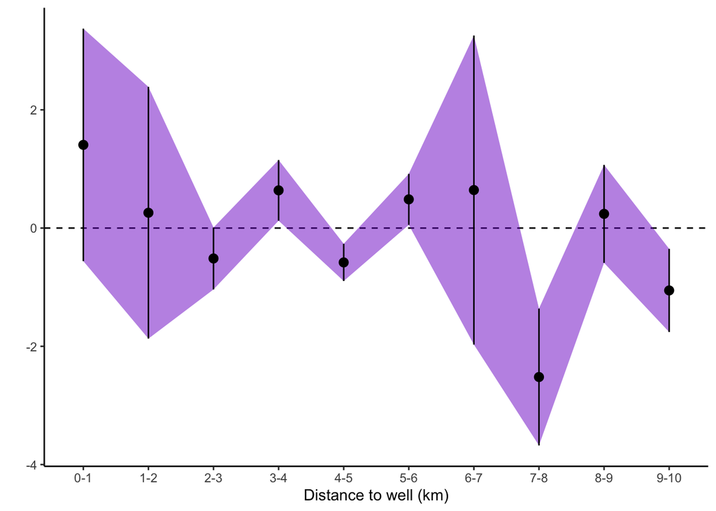

**Downwind**

*Table*

```
## # A tibble: 10 x 5
##    distance direction point_est  ci_lower ci_upper
##    <chr>    <chr>         <dbl>     <dbl>    <dbl>
##  1 0-1      Downwind     1.22   -2.24        4.67
##  2 1-2      Downwind    -0.875  -4.08        2.33
##  3 2-3      Downwind    -1.47   -1.76       -1.17
##  4 3-4      Downwind     0.0251 -0.192       0.243
##  5 4-5      Downwind     0.517   0.0465      0.987
##  6 5-6      Downwind     1.66    1.03        2.29
##  7 6-7      Downwind     0.406  -1.48        2.29
##  8 7-8      Downwind     1.24   -0.000793    2.48
##  9 8-9      Downwind    -0.326  -1.33        0.679
## 10 9-10     Downwind     1.77    1.05        2.48
```

*Figure*

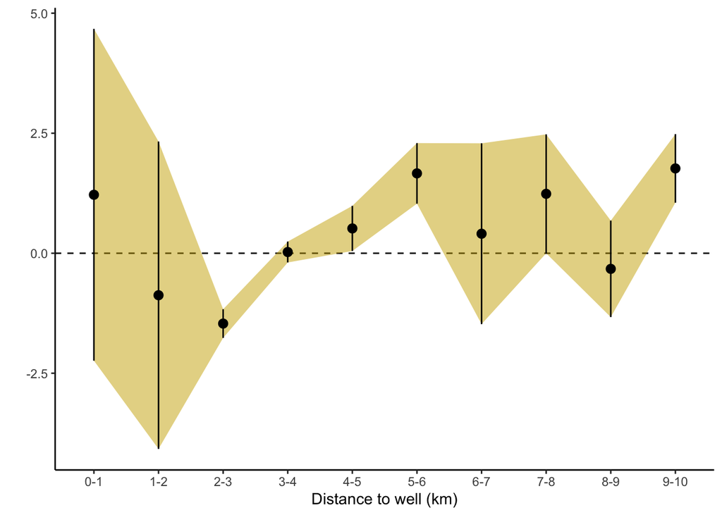

## Pollutant: Ozone (O3)

Descriptive statistics:

- n monitor days = 1262263
- n monitors in analytic data = 284

#### Linear model with monitor + month + basin:year FE

```
##
## Call:
##    felm(formula = o3_concentration_daily_max ~ wells_new_0to1km +      wells_new_1to2km + wells_new_2to3km + wells_new_3to4km +      wells_new_4to5km + wells_new_5to6km + wells_new_6to7km +      wells_new_7to8km + wells_new_8to9km + wells_new_9to10km +      wells_dw_new_0to1km + wells_dw_new_1to2…
##
## Residuals:
##       Min        1Q    Median        3Q       Max
## -0.062764 -0.006712 -0.000077  0.006466  0.087556
##
## Coefficients:
##                        Estimate Std. Error t value Pr(>|t|)
## wells_new_0to1km     -5.092e-04  1.240e-04  -4.106 4.02e-05 ***
## wells_new_1to2km      7.731e-05  5.088e-05   1.519 0.128676
## wells_new_2to3km      3.721e-04  6.513e-05   5.713 1.11e-08 ***
## wells_new_3to4km      3.168e-04  4.870e-05   6.506 7.73e-11 ***
## wells_new_4to5km      9.284e-05  6.187e-05   1.501 0.133453
## wells_new_5to6km     -1.961e-04  3.849e-05  -5.097 3.46e-07 ***
## wells_new_6to7km     -2.659e-05  5.698e-05  -0.467 0.640767
## wells_new_7to8km      1.453e-04  3.823e-05   3.802 0.000144 ***
## wells_new_8to9km      1.789e-04  6.551e-05   2.731 0.006320 **
## wells_new_9to10km    -3.843e-04  8.678e-05  -4.428 9.50e-06 ***
## wells_dw_new_0to1km   2.704e-04  2.403e-04   1.125 0.260387
## wells_dw_new_1to2km  -2.768e-04  7.822e-05  -3.539 0.000402 ***
## wells_dw_new_2to3km   2.443e-05  6.044e-05   0.404 0.686083
## wells_dw_new_3to4km  -2.727e-04  3.956e-05  -6.892 5.51e-12 ***
## wells_dw_new_4to5km  -3.309e-04  4.075e-05  -8.120 4.68e-16 ***
## wells_dw_new_5to6km   7.304e-05  3.392e-05   2.153 0.031286 *
## wells_dw_new_6to7km  -5.849e-05  6.931e-05  -0.844 0.398747
## wells_dw_new_7to8km  -3.660e-05  4.945e-05  -0.740 0.459295
## wells_dw_new_8to9km   3.839e-05  4.917e-05   0.781 0.434929
## wells_dw_new_9to10km -5.256e-04  9.082e-05  -5.788 7.14e-09 ***
## narr_precip           2.385e-05  3.967e-06   6.013 1.82e-09 ***
## narr_temp             1.057e-03  3.987e-06 265.157  < 2e-16 ***
## ---
## Signif. codes:  0 '***' 0.001 '**' 0.01 '*' 0.05 '.' 0.1 ' ' 1
##
## Residual standard error: 0.0104 on 448337 degrees of freedom
##   (813676 observations deleted due to missingness)
## Multiple R-squared(full model): 0.5541   Adjusted R-squared: 0.5539
## Multiple R-squared(proj model): 0.1369   Adjusted R-squared: 0.1364
## F-statistic(full model): 2238 on 249 and 448337 DF, p-value: < 2.2e-16
## F-statistic(proj model):  3231 on 22 and 448337 DF, p-value: < 2.2e-16
## *** Standard errors may be too high due to more than 2 groups and exactDOF=FALSE
```

**Upwind**

*Table*

```
## # A tibble: 10 x 5
##    distance direction  point_est   ci_lower   ci_upper
##    <chr>    <chr>          <dbl>      <dbl>      <dbl>
##  1 0-1      Upwind    -0.000509  -0.000752  -0.000266
##  2 1-2      Upwind     0.0000773 -0.0000224  0.000177
##  3 2-3      Upwind     0.000372   0.000244   0.000500
##  4 3-4      Upwind     0.000317   0.000221   0.000412
##  5 4-5      Upwind     0.0000928 -0.0000284  0.000214
##  6 5-6      Upwind    -0.000196  -0.000272  -0.000121
##  7 6-7      Upwind    -0.0000266 -0.000138   0.0000851
##  8 7-8      Upwind     0.000145   0.0000704  0.000220
##  9 8-9      Upwind     0.000179   0.0000505  0.000307
## 10 9-10     Upwind    -0.000384  -0.000554  -0.000214
```

*Figure*

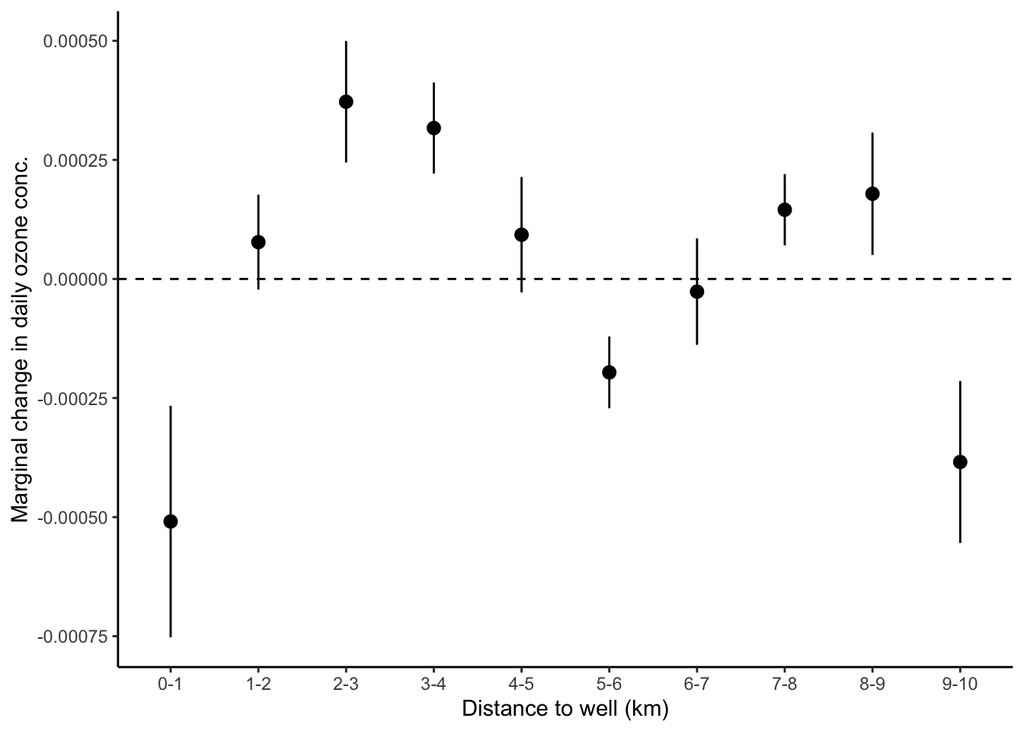

**Downwind**

*Table*

```
## # A tibble: 10 x 5
##    distance direction  point_est    ci_lower   ci_upper
##    <chr>    <chr>          <dbl>       <dbl>      <dbl>
##  1 0-1      Downwind   0.000270  -0.000201    0.000741
##  2 1-2      Downwind  -0.000277  -0.000430   -0.000124
##  3 2-3      Downwind   0.0000244 -0.0000940   0.000143
##  4 3-4      Downwind  -0.000273  -0.000350   -0.000195
##  5 4-5      Downwind  -0.000331  -0.000411   -0.000251
##  6 5-6      Downwind   0.0000730  0.00000656  0.000140
##  7 6-7      Downwind  -0.0000585 -0.000194    0.0000774
##  8 7-8      Downwind  -0.0000366 -0.000134    0.0000603
##  9 8-9      Downwind   0.0000384 -0.0000580   0.000135
## 10 9-10     Downwind  -0.000526  -0.000704   -0.000348
```

*Figure*

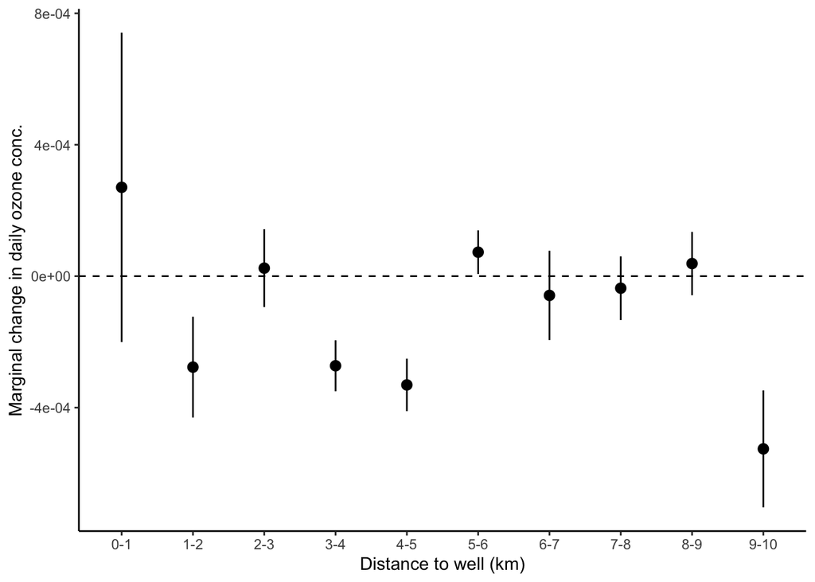

**Count of new wells within 1-km bins of O3 monitors**

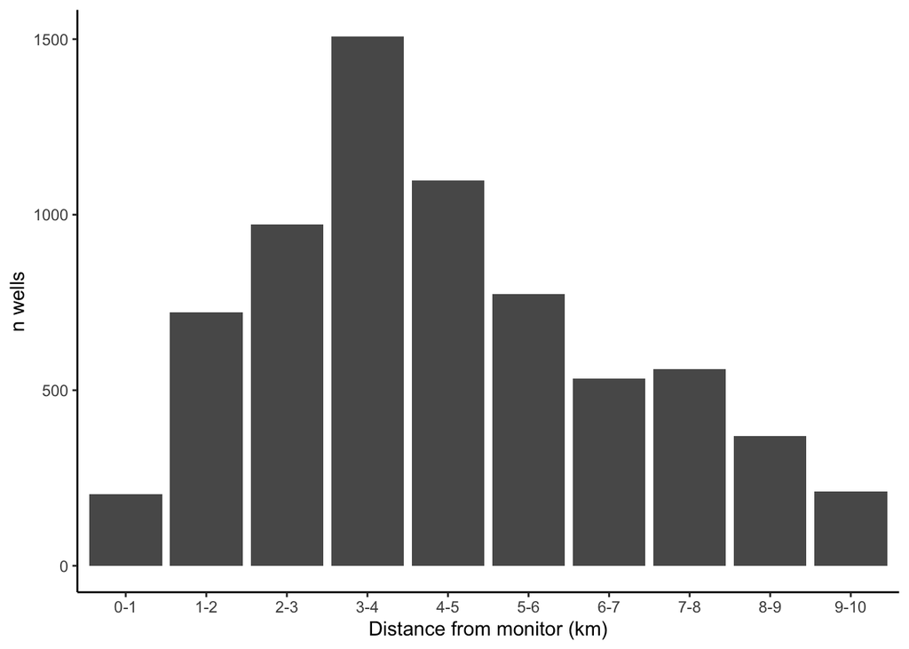

## Pollutant: Sulfur Dioxide (SO2)

Descriptive statistics:

- n monitor days = 245116
- n monitors in analytic data = 65

#### Linear model with monitor + month + basin:year FE

```
##
## Call:
##    felm(formula = so2_concentration_daily_max ~ wells_new_0to1km +      wells_new_1to2km + wells_new_2to3km + wells_new_3to4km +      wells_new_4to5km + wells_new_5to6km + wells_new_6to7km +      wells_new_7to8km + wells_new_8to9km + wells_new_9to10km +      wells_dw_new_0to1km + wells_dw_new_1to…
##
## Residuals:
##    Min     1Q Median     3Q    Max
## -15.47  -2.31  -0.41   1.38 344.15
##
## Coefficients:
##                       Estimate Std. Error t value Pr(>|t|)
## wells_new_0to1km      3.100044   1.054226   2.941 0.003277 **
## wells_new_1to2km     -0.411766   0.335821  -1.226 0.220146
## wells_new_2to3km     -0.714732   0.182589  -3.914 9.07e-05 ***
## wells_new_3to4km      0.024588   0.108289   0.227 0.820382
## wells_new_4to5km      0.101526   0.114972   0.883 0.377212
## wells_new_5to6km      0.164348   0.049012   3.353 0.000799 ***
## wells_new_6to7km     -0.012063   0.084990  -0.142 0.887133
## wells_new_7to8km     -0.096815   0.031474  -3.076 0.002098 **
## wells_new_8to9km     -0.116482   0.084424  -1.380 0.167673
## wells_new_9to10km    -0.128048   0.188973  -0.678 0.498027
## wells_dw_new_0to1km   2.030356   1.771873   1.146 0.251847
## wells_dw_new_1to2km  -0.540190   0.472283  -1.144 0.252716
## wells_dw_new_2to3km  -1.701287   0.161627 -10.526  < 2e-16 ***
## wells_dw_new_3to4km   0.696672   0.171094   4.072 4.67e-05 ***
## wells_dw_new_4to5km   0.029423   0.234151   0.126 0.900004
## wells_dw_new_5to6km   0.126114   0.103484   1.219 0.222971
## wells_dw_new_6to7km  -0.248416   0.121400  -2.046 0.040734 *
## wells_dw_new_7to8km  -0.070983   0.051299  -1.384 0.166452
## wells_dw_new_8to9km  -0.211610   0.130164  -1.626 0.104013
## wells_dw_new_9to10km  0.245180   0.279837   0.876 0.380948
## narr_precip          -0.094624   0.005877 -16.099  < 2e-16 ***
## narr_temp             0.108090   0.006450  16.758  < 2e-16 ***
## narr_wind_speed      -0.055037   0.011439  -4.811 1.50e-06 ***
## ---
## Signif. codes:  0 '***' 0.001 '**' 0.01 '*' 0.05 '.' 0.1 ' ' 1
##
## Residual standard error: 6.828 on 104815 degrees of freedom
##   (140178 observations deleted due to missingness)
## Multiple R-squared(full model): 0.2101   Adjusted R-squared: 0.2092
## Multiple R-squared(proj model): 0.008057   Adjusted R-squared: 0.006902
## F-statistic(full model):228.5 on 122 and 104815 DF, p-value: < 2.2e-16
## F-statistic(proj model): 37.01 on 23 and 104815 DF, p-value: < 2.2e-16
## *** Standard errors may be too high due to more than 2 groups and exactDOF=FALSE
```

**Upwind**

*Table*

```
## # A tibble: 10 x 5
##    distance direction point_est ci_lower ci_upper
##    <chr>    <chr>         <dbl>    <dbl>    <dbl>
##  1 0-1      Upwind       3.10     1.03     5.17
##  2 1-2      Upwind      -0.412   -1.07     0.246
##  3 2-3      Upwind      -0.715   -1.07    -0.357
##  4 3-4      Upwind       0.0246  -0.188    0.237
##  5 4-5      Upwind       0.102   -0.124    0.327
##  6 5-6      Upwind       0.164    0.0683   0.260
##  7 6-7      Upwind      -0.0121  -0.179    0.155
##  8 7-8      Upwind      -0.0968  -0.159   -0.0351
##  9 8-9      Upwind      -0.116   -0.282    0.0490
## 10 9-10     Upwind      -0.128   -0.498    0.242
```

*Figure*

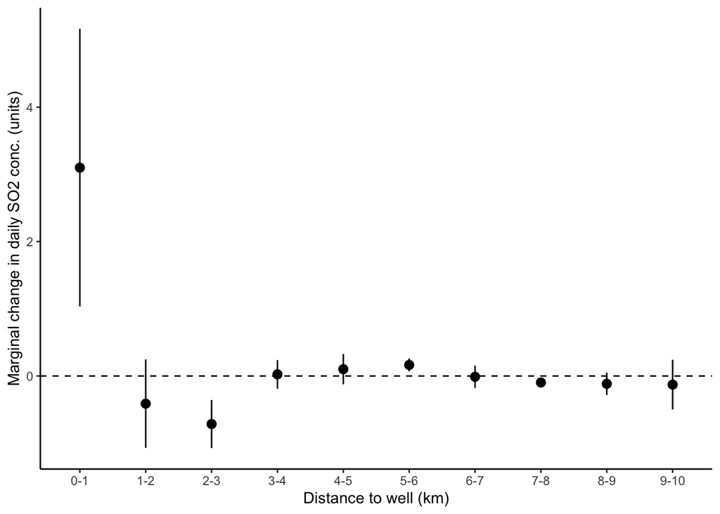

**Downwind**

*Table*

```
## # A tibble: 10 x 5
##    distance direction point_est ci_lower ci_upper
##    <chr>    <chr>         <dbl>    <dbl>    <dbl>
##  1 0-1      Downwind     2.03    -1.44     5.50
##  2 1-2      Downwind    -0.540   -1.47     0.385
##  3 2-3      Downwind    -1.70    -2.02    -1.38
##  4 3-4      Downwind     0.697    0.361    1.03
##  5 4-5      Downwind     0.0294  -0.430    0.488
##  6 5-6      Downwind     0.126   -0.0767   0.329
##  7 6-7      Downwind    -0.248   -0.486   -0.0105
##  8 7-8      Downwind    -0.0710  -0.172    0.0296
##  9 8-9      Downwind    -0.212   -0.467    0.0435
## 10 9-10     Downwind     0.245   -0.303    0.794
```

**Figure**

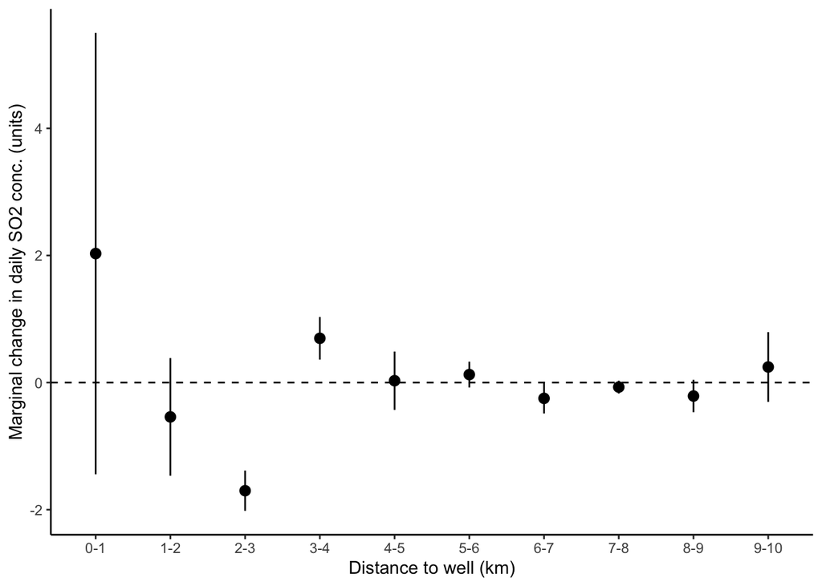

[figure not shown]

# Particulate Matter

## Pollutant: Fine particulate matter (PM2.5)

### Urban

Descriptive statistics:

- n monitor days = 418135
- n monitors in analytic data = 159

#### Adjusted linear regression model with monitor + month + basin:year FE adjusted for temp + precip

```
##
## Call:
##    felm(formula = pm2.5_concentration_daily_mean ~ wells_new_0to1km +      wells_new_1to2km + wells_new_2to3km + wells_new_3to4km +      wells_new_4to5km + wells_new_5to6km + wells_new_6to7km +      wells_new_7to8km + wells_new_8to9km + wells_new_9to10km +      wells_dw_new_0to1km + wells_dw_new_…
##
## Residuals:
##     Min      1Q  Median      3Q     Max
## -28.553  -4.736  -1.119   2.810 264.714
##
## Coefficients:
##                       Estimate Std. Error t value Pr(>|t|)
## wells_new_0to1km            NA         NA      NA       NA
## wells_new_1to2km      1.590504   0.934276   1.702 0.088684 .
## wells_new_2to3km     -0.465274   0.400225  -1.163 0.245022
## wells_new_3to4km     -0.289285   0.249460  -1.160 0.246195
## wells_new_4to5km     -0.120586   0.273136  -0.441 0.658860
## wells_new_5to6km     -0.040478   0.132602  -0.305 0.760171
## wells_new_6to7km      0.058625   0.116466   0.503 0.614709
## wells_new_7to8km      0.042222   0.036958   1.142 0.253274
## wells_new_8to9km     -0.136903   0.087563  -1.563 0.117942
## wells_new_9to10km     0.485224   0.079572   6.098 1.08e-09 ***
## wells_dw_new_0to1km         NA         NA      NA       NA
## wells_dw_new_1to2km  -0.624324   0.857543  -0.728 0.466591
## wells_dw_new_2to3km   0.855366   0.237743   3.598 0.000321 ***
## wells_dw_new_3to4km   0.232481   0.246931   0.941 0.346459
## wells_dw_new_4to5km   0.334678   0.270564   1.237 0.216103
## wells_dw_new_5to6km  -0.108297   0.124144  -0.872 0.383016
## wells_dw_new_6to7km   0.023288   0.120992   0.192 0.847367
## wells_dw_new_7to8km  -0.057669   0.057590  -1.001 0.316652
## wells_dw_new_8to9km  -0.162337   0.080661  -2.013 0.044159 *
## wells_dw_new_9to10km -0.189160   0.070084  -2.699 0.006955 **
## narr_precip          -0.270780   0.005767 -46.951  < 2e-16 ***
## narr_temp            -0.075421   0.005550 -13.588  < 2e-16 ***
## narr_wind_speed      -1.120677   0.013509 -82.957  < 2e-16 ***
## ---
## Signif. codes:  0 '***' 0.001 '**' 0.01 '*' 0.05 '.' 0.1 ' ' 1
##
## Residual standard error: 8.756 on 161914 degrees of freedom
##   (256026 observations deleted due to missingness)
## Multiple R-squared(full model): 0.3002   Adjusted R-squared: 0.2994
## Multiple R-squared(proj model): 0.0699   Adjusted R-squared: 0.06879
## F-statistic(full model):  358 on 194 and 161914 DF, p-value: < 2.2e-16
## F-statistic(proj model): 529.1 on 23 and 161914 DF, p-value: < 2.2e-16
## *** Standard errors may be too high due to more than 2 groups and exactDOF=FALSE
```

**Upwind wells**

*Table*

```
## # A tibble: 10 x 5
##    distance direction point_est ci_lower ci_upper
##    <chr>    <chr>         <dbl>    <dbl>    <dbl>
##  1 0-1      Upwind     NaN      NaN      NaN
##  2 1-2      Upwind       1.59    -0.241    3.42
##  3 2-3      Upwind      -0.465   -1.25     0.319
##  4 3-4      Upwind      -0.289   -0.778    0.200
##  5 4-5      Upwind      -0.121   -0.656    0.415
##  6 5-6      Upwind      -0.0405  -0.300    0.219
##  7 6-7      Upwind       0.0586  -0.170    0.287
##  8 7-8      Upwind       0.0422  -0.0302   0.115
##  9 8-9      Upwind      -0.137   -0.309    0.0347
## 10 9-10     Upwind       0.485    0.329    0.641
```

*Figure*

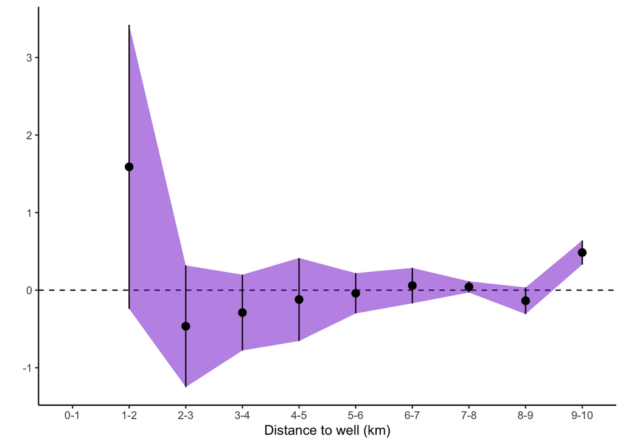

**Downwind wells**

*Table*

```
## # A tibble: 10 x 5
##    distance direction point_est ci_lower  ci_upper
##    <chr>    <chr>         <dbl>    <dbl>     <dbl>
##  1 0-1      Downwind   NaN       NaN     NaN
##  2 1-2      Downwind    -0.624    -2.31    1.06
##  3 2-3      Downwind     0.855     0.389   1.32
##  4 3-4      Downwind     0.232    -0.251   0.716
##  5 4-5      Downwind     0.335    -0.196   0.865
##  6 5-6      Downwind    -0.108    -0.352   0.135
##  7 6-7      Downwind     0.0233   -0.214   0.260
##  8 7-8      Downwind    -0.0577   -0.171   0.0552
##  9 8-9      Downwind    -0.162    -0.320  -0.00424
## 10 9-10     Downwind    -0.189    -0.327  -0.0518
```

*Figure*

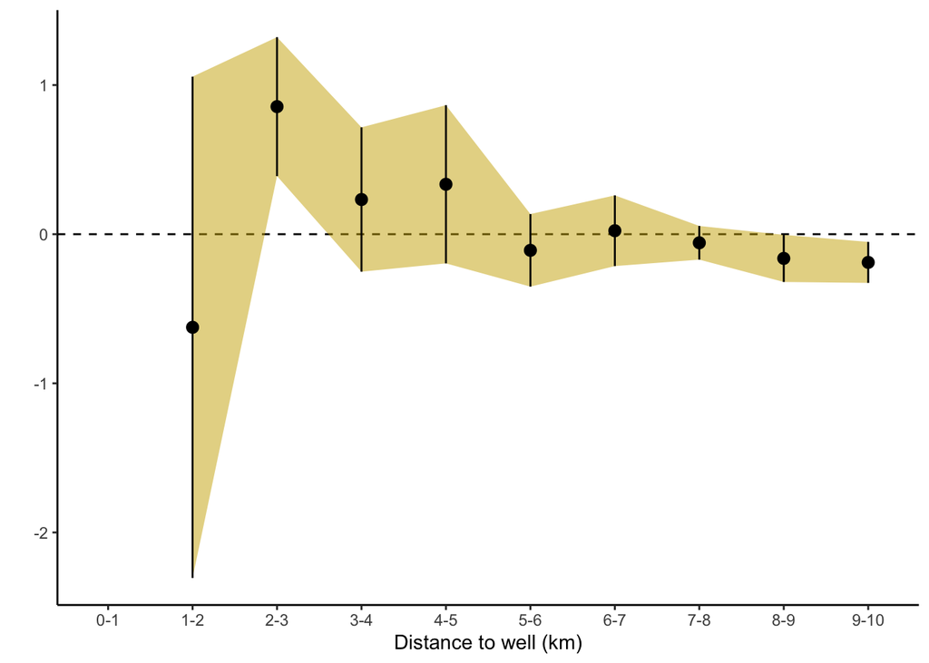

### Rural

Descriptive statistics:

- n monitor days = 128589
- n monitors in analytic data = 58

#### Adjusted linear regression model with monitor + month + basin:year FE adjusted for temp + precip

```
##
## Call:
##    felm(formula = pm2.5_concentration_daily_mean ~ wells_new_0to1km +      wells_new_1to2km + wells_new_2to3km + wells_new_3to4km +      wells_new_4to5km + wells_new_5to6km + wells_new_6to7km +      wells_new_7to8km + wells_new_8to9km + wells_new_9to10km +      wells_dw_new_0to1km + wells_dw_new_…
##
## Residuals:
##    Min     1Q Median     3Q    Max
## -18.65  -3.64  -0.94   2.05 545.91
##
## Coefficients:
##                       Estimate Std. Error t value Pr(>|t|)
## wells_new_0to1km            NA         NA      NA       NA
## wells_new_1to2km            NA         NA      NA       NA
## wells_new_2to3km      1.257738   0.365584   3.440 0.000581 ***
## wells_new_3to4km      0.714423   0.666481   1.072 0.283755
## wells_new_4to5km      3.830207   0.939572   4.077 4.58e-05 ***
## wells_new_5to6km     -0.955114   0.411976  -2.318 0.020434 *
## wells_new_6to7km     -0.175004   0.361818  -0.484 0.628614
## wells_new_7to8km      0.144917   0.212825   0.681 0.495925
## wells_new_8to9km     -0.735981   0.297020  -2.478 0.013220 *
## wells_new_9to10km     1.319757   0.266208   4.958 7.16e-07 ***
## wells_dw_new_0to1km         NA         NA      NA       NA
## wells_dw_new_1to2km         NA         NA      NA       NA
## wells_dw_new_2to3km  -1.616705   0.673667  -2.400 0.016405 *
## wells_dw_new_3to4km   2.329719   0.468475   4.973 6.62e-07 ***
## wells_dw_new_4to5km   2.599237   1.121881   2.317 0.020516 *
## wells_dw_new_5to6km  -0.370914   0.459157  -0.808 0.419201
## wells_dw_new_6to7km   0.209046   0.398584   0.524 0.599954
## wells_dw_new_7to8km  -0.078950   0.215025  -0.367 0.713496
## wells_dw_new_8to9km   0.543804   0.406009   1.339 0.180451
## wells_dw_new_9to10km  0.666861   0.381469   1.748 0.080447 .
## narr_precip          -0.149752   0.008842 -16.936  < 2e-16 ***
## narr_temp             0.079373   0.009694   8.188 2.72e-16 ***
## narr_wind_speed      -0.552973   0.022927 -24.119  < 2e-16 ***
## ---
## Signif. codes:  0 '***' 0.001 '**' 0.01 '*' 0.05 '.' 0.1 ' ' 1
##
## Residual standard error: 7.93 on 46527 degrees of freedom
##   (81942 observations deleted due to missingness)
## Multiple R-squared(full model): 0.1672   Adjusted R-squared: 0.165
## Multiple R-squared(proj model): 0.02855   Adjusted R-squared: 0.02606
## F-statistic(full model):78.47 on 119 and 46527 DF, p-value: < 2.2e-16
## F-statistic(proj model): 59.44 on 23 and 46527 DF, p-value: < 2.2e-16
## *** Standard errors may be too high due to more than 2 groups and exactDOF=FALSE
```

**Upwind wells**

*Table*

```
## # A tibble: 10 x 5
##    distance direction point_est ci_lower ci_upper
##    <chr>    <chr>         <dbl>    <dbl>    <dbl>
##  1 0-1      Upwind      NaN      NaN      NaN
##  2 1-2      Upwind      NaN      NaN      NaN
##  3 2-3      Upwind        1.26     0.541    1.97
##  4 3-4      Upwind        0.714   -0.592    2.02
##  5 4-5      Upwind        3.83     1.99     5.67
##  6 5-6      Upwind       -0.955   -1.76    -0.148
##  7 6-7      Upwind       -0.175   -0.884    0.534
##  8 7-8      Upwind        0.145   -0.272    0.562
##  9 8-9      Upwind       -0.736   -1.32    -0.154
## 10 9-10     Upwind        1.32     0.798    1.84
```

*Figure*

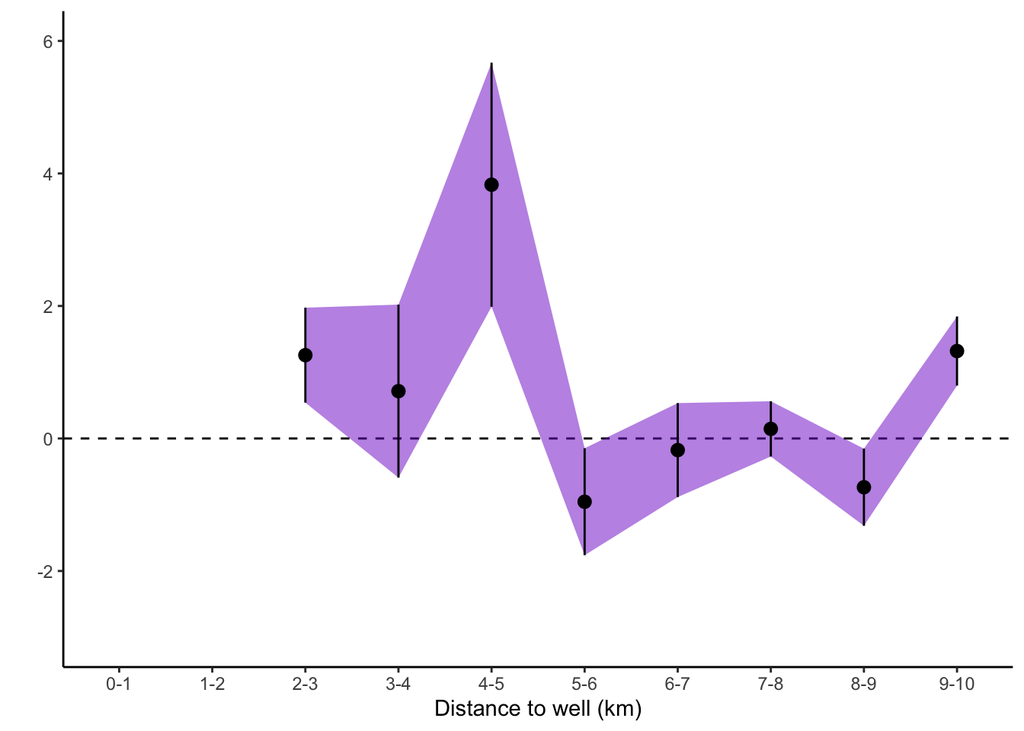

**Downwind wells**

*Table*

```
## # A tibble: 10 x 5
##    distance direction point_est ci_lower ci_upper
##    <chr>    <chr>         <dbl>    <dbl>    <dbl>
##  1 0-1      Downwind   NaN      NaN       NaN
##  2 1-2      Downwind   NaN      NaN       NaN
##  3 2-3      Downwind    -1.62    -2.94     -0.296
##  4 3-4      Downwind     2.33     1.41      3.25
##  5 4-5      Downwind     2.60     0.400     4.80
##  6 5-6      Downwind    -0.371   -1.27      0.529
##  7 6-7      Downwind     0.209   -0.572     0.990
##  8 7-8      Downwind    -0.0790  -0.500     0.343
##  9 8-9      Downwind     0.544   -0.252     1.34
## 10 9-10     Downwind     0.667   -0.0808    1.41
```

*Figure*

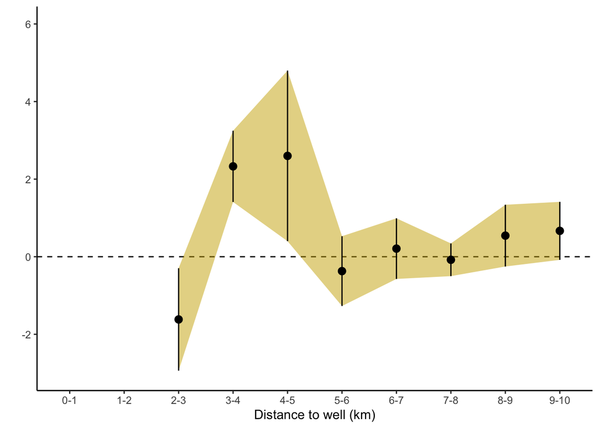

**Count of new wells within 1-km bins of PM2.5 monitors**

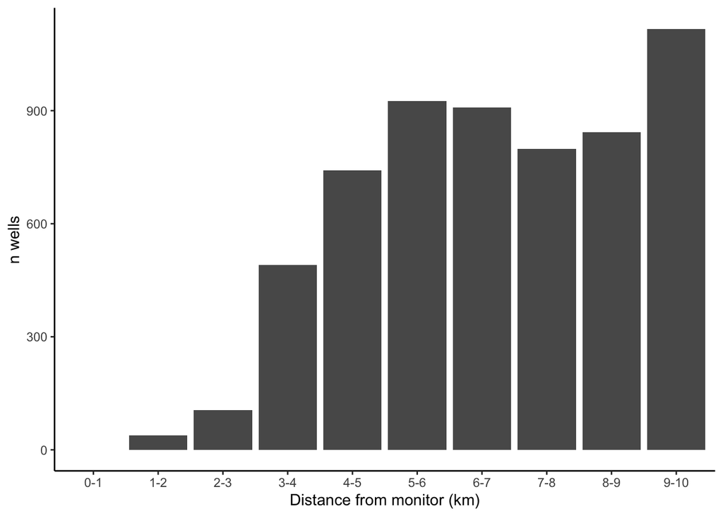

# VOCs

## Pollutant: Total NMOC

Descriptive statistics:

- n monitor days = 94607
- n monitors in analytic data = 49

#### Linear model with monitor + month + basin:year FE

```
##
## Call:
##    felm(formula = total_nmoc ~ wells_new_0to1km + wells_new_1to2km +      wells_new_2to3km + wells_new_3to4km + wells_new_4to5km +      wells_new_5to6km + wells_new_6to7km + wells_new_7to8km +      wells_new_8to9km + wells_new_9to10km + wells_dw_new_0to1km +      wells_dw_new_1to2km + wells_dw_ne…
##
## Residuals:
##    Min     1Q Median     3Q    Max
## -381.6  -49.5   -7.2   29.1 8659.1
##
## Coefficients:
##                      Estimate Std. Error t value Pr(>|t|)
## wells_new_0to1km           NA         NA      NA       NA
## wells_new_1to2km     -34.0390    19.3580  -1.758 0.078687 .
## wells_new_2to3km       8.3732     7.8885   1.061 0.288495
## wells_new_3to4km      -8.5060     5.9021  -1.441 0.149538
## wells_new_4to5km      -9.1833     6.4875  -1.416 0.156914
## wells_new_5to6km      -0.5533     3.4646  -0.160 0.873110
## wells_new_6to7km      16.4058     4.4220   3.710 0.000207 ***
## wells_new_7to8km       2.0128     4.2832   0.470 0.638416
## wells_new_8to9km       3.8545     3.9320   0.980 0.326948
## wells_new_9to10km      1.9961     2.1084   0.947 0.343760
## wells_dw_new_0to1km        NA         NA      NA       NA
## wells_dw_new_1to2km  -24.5428    16.4642  -1.491 0.136053
## wells_dw_new_2to3km   -3.5610     4.1784  -0.852 0.394080
## wells_dw_new_3to4km   -7.2433     2.7160  -2.667 0.007659 **
## wells_dw_new_4to5km   25.1387     5.6665   4.436 9.17e-06 ***
## wells_dw_new_5to6km   -9.8942     2.5466  -3.885 0.000102 ***
## wells_dw_new_6to7km   13.5797     4.4558   3.048 0.002308 **
## wells_dw_new_7to8km   -7.0337     2.1707  -3.240 0.001195 **
## wells_dw_new_8to9km  -18.4467     2.7258  -6.768 1.33e-11 ***
## wells_dw_new_9to10km  -7.2072     1.5628  -4.612 4.00e-06 ***
## narr_precip           -2.5785     0.2104 -12.256  < 2e-16 ***
## narr_temp              2.5195     0.1848  13.637  < 2e-16 ***
## narr_wind_speed      -11.5332     0.5449 -21.167  < 2e-16 ***
## ---
## Signif. codes:  0 '***' 0.001 '**' 0.01 '*' 0.05 '.' 0.1 ' ' 1
##
## Residual standard error: 142.4 on 42183 degrees of freedom
##   (52284 observations deleted due to missingness)
## Multiple R-squared(full model): 0.3077   Adjusted R-squared: 0.3054
## Multiple R-squared(proj model): 0.02744   Adjusted R-squared: 0.02423
## F-statistic(full model):134.9 on 139 and 42183 DF, p-value: < 2.2e-16
## F-statistic(proj model): 51.74 on 23 and 42183 DF, p-value: < 2.2e-16
## *** Standard errors may be too high due to more than 2 groups and exactDOF=FALSE
```

**Upwind**

*Table*

```
## # A tibble: 10 x 5
##    distance direction point_est ci_lower ci_upper
##    <chr>    <chr>         <dbl>    <dbl>    <dbl>
##  1 0-1      Upwind      NaN       NaN      NaN
##  2 1-2      Upwind      -34.0     -72.0      3.90
##  3 2-3      Upwind        8.37     -7.09    23.8
##  4 3-4      Upwind       -8.51    -20.1      3.06
##  5 4-5      Upwind       -9.18    -21.9      3.53
##  6 5-6      Upwind       -0.553    -7.34     6.24
##  7 6-7      Upwind       16.4       7.74    25.1
##  8 7-8      Upwind        2.01     -6.38    10.4
##  9 8-9      Upwind        3.85     -3.85    11.6
## 10 9-10     Upwind        2.00     -2.14     6.13
```

**Figure**

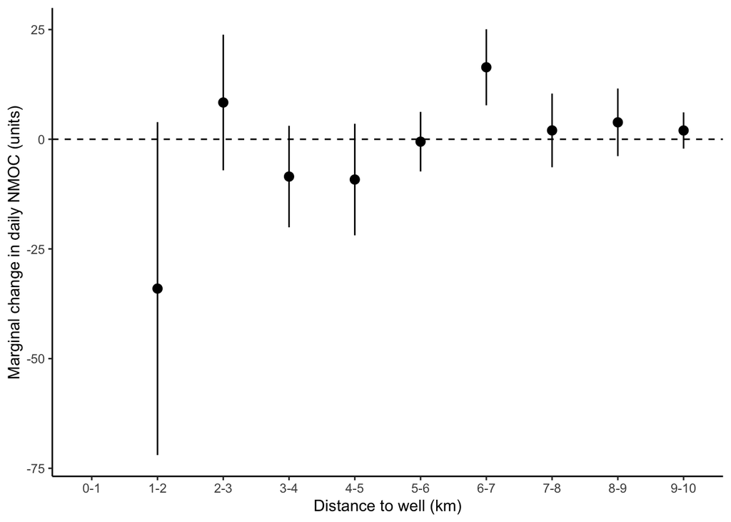

**Downwind**

*Table*

```
## # A tibble: 10 x 5
##    distance direction point_est ci_lower ci_upper
##    <chr>    <chr>         <dbl>    <dbl>    <dbl>
##  1 0-1      Downwind     NaN      NaN      NaN
##  2 1-2      Downwind     -24.5    -56.8      7.73
##  3 2-3      Downwind      -3.56   -11.8      4.63
##  4 3-4      Downwind      -7.24   -12.6     -1.92
##  5 4-5      Downwind      25.1     14.0     36.2
##  6 5-6      Downwind      -9.89   -14.9     -4.90
##  7 6-7      Downwind      13.6      4.85    22.3
##  8 7-8      Downwind      -7.03   -11.3     -2.78
##  9 8-9      Downwind     -18.4    -23.8    -13.1
## 10 9-10     Downwind      -7.21   -10.3     -4.14
```

**Figure**

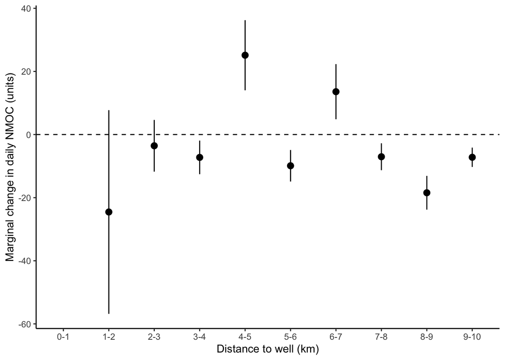

**Count of new wells within 1-km bins of monitor**

[figure not shown]